# R Notebook

# 1. Online hospitality company Airbnb

## 1.1 Reading Dataset and printing Summary

```r
### Reading Dataset
data <- read.csv("listings.csv")
head(data)
```

|  | id | listing_url | scrape_id | last_scraped | name | description | neighborhood_overview | picture_url | host_id | host_url | host_name | host_since | host_location | host_about | host_response_time | host_response_rate | host_acceptance_rate | host_is_superhost | host_thumbnail_url | host_picture_url | host_neighbourhood | host_listings_count | host_total_listings_count | host_verifications | host_has_profile_pic | host_identity_verified | neighbourhood | neighbourhood_cleansed | neighbourhood_group_cleansed | … |
| --- | --- | --- | --- | --- | --- | --- | --- | --- | --- | --- | --- | --- | --- | --- | --- | --- | --- | --- | --- | --- | --- | --- | --- | --- | --- | --- | --- | --- | --- | --- |
| 1 | 11156 | https://www.airbnb.com/rooms/11156 | 2.022061e+13 | 2022-06-06 | An Oasis in the City | Very central to the city which can be reached by an easy walk or by bus, with transport at the door, if required, and all amenities within easy reach.The spacePotts Pt. is a vibrant and popular inner-… | It is very close to everything and everywhere, has many trees along the streets and is in a beautiful part of the city | https://a0.muscache.com/pictures/2797669/17895d03_original.jpg | 40855 | https://www.airbnb.com/users/show/40855 | Colleen | 2009-09-23 | Potts Point, New South Wales, Australia | Recently retired, I've lived & worked on 4 continents & over the years have travelled thru about 50 countries. I live in inner-Sydney within walking distance of most places (except the beaches, which … | N/A | N/A | 100% | f | https://a0.muscache.com/im/users/40855/profile_pic/1259121939/original.jpg?aki_policy=profile_small | https://a0.muscache.com/im/users/40855/profile_pic/1259121939/original.jpg?aki_policy=profile_x_medium | Potts Point | 1 | 1 | ['email', 'phone'] | t | f | Potts Point, New South Wales, Australia | Sydney | NA | … |
| 2 | 14250 | https://www.airbnb.com/rooms/14250 | 2.022061e+13 | 2022-06-06 | Manly Harbour House | Beautifully renovated, spacious and quiet, our 3 Bedroom, 3 Bathroom home is only a 10 minute walk to beaches in Fairlight or Forty Baskets, or a 30 minute walk to Manly via the coastal promenade, or … | Balgowlah Heights is one of the most prestigious areas on the Northern Beaches. Filled with seaside character and a boutique way of living, this suburb offers everything you could need. Located approx… | https://a0.muscache.com/pictures/56935671/fdb8c0bf_original.jpg | 55948 | https://www.airbnb.com/users/show/55948 | Heidi | 2009-11-20 | Sydney, New South Wales, Australia | I am a Canadian who has made Australia her home for over twenty years. I appreciate a special place to stay, having had many travel adventures myself. Our home is in Balgowlah Heights, a pretty harbou… | within an hour | 100% | 70% | f | https://a0.muscache.com/im/users/55948/profile_pic/1327370146/original.jpg?aki_policy=profile_small | https://a0.muscache.com/im/users/55948/profile_pic/1327370146/original.jpg?aki_policy=profile_x_medium | Balgowlah | 2 | 2 | ['email', 'phone'] | t | t | Balgowlah, New South Wales, Australia | Manly | NA | … |
| 3 | 751568 | https://www.airbnb.com/rooms/751568 | 2.022061e+13 | 2022-06-06 | Boho Terrace Hip Centre Syd | * Please not that the second bedroom now has a set of single bunk beds, not the day bed as per the photos. The living room also has a real couch rather than the palette couch*.You'll feel at home in o… | Erskineville is at the junction of 3 train stations, has a great relaxed family, hipster vibe with leafy streets and a quaint village. We are only 5 mins walk from the vibrant Newtown and 10 mins from… | https://a0.muscache.com/pictures/61955412/d53e786f_original.jpg | 334978 | https://www.airbnb.com/users/show/334978 | Cc | 2011-01-04 | Erskineville, New South Wales, Australia | Communications Manager for an Architect. Married to Ulysses. Currently studying for a traveling research scholarship on signage and architecture. | N/A | N/A | 50% | f | https://a0.muscache.com/im/users/334978/profile_pic/1294358309/original.jpg?aki_policy=profile_small | https://a0.muscache.com/im/users/334978/profile_pic/1294358309/original.jpg?aki_policy=profile_x_medium | Erskineville | 1 | 1 | ['email', 'phone'] | t | t | Erskineville, New South Wales, Australia | Sydney | NA | … |
| 4 | 923880 | https://www.airbnb.com/rooms/923880 | 2.022061e+13 | 2022-06-06 | IMMACULATE FURNISHED 1 BEDROOM NEAR COOGEE BEACH | This is quality accommodation with a luxurious coastal look and feel. What you see in the picture is what you get and more. It has been equipped with everything you'll need to kick back and relax whil… | The neighbourhood is in a quiet residential nook, but not out of the way. It is in Randwick near "The Spot". "The Spot" is a very popular destination with the locals and is dotted with cafes and resta… | https://a0.muscache.com/pictures/232ef434-cc91-4c1e-a8bb-fe688fa351ef.jpg | 4969200 | https://www.airbnb.com/users/show/4969200 | Jasmin | 2013-02-04 | Sydney, New South Wales, Australia | I'm a friendly, honest, reliable and genuinely helpful host and strive to make your stay as comfortable and memorable as possible. I have a lot of local knowledge so if you need some tips or informati… | within a few hours | 100% | 82% | f | https://a0.muscache.com/im/users/4969200/profile_pic/1407153467/original.jpg?aki_policy=profile_small | https://a0.muscache.com/im/users/4969200/profile_pic/1407153467/original.jpg?aki_policy=profile_x_medium | Randwick | 2 | 2 | ['email', 'phone', 'work_email'] | t | t | Randwick, New South Wales, Australia | Randwick | NA | … |
| 5 | 15253 | https://www.airbnb.com/rooms/15253 | 2.022061e+13 | 2022-06-06 | Unique Designer Rooftop Apartment in City Location | You will be staying in a unique apartment on the top floor of a centrally located boutique building. As the apartment is spread over 2 levels guests have a high level of privacy and security. The room… | The location is really central and there is number of things to do and see all within a few kilometres; Stanley St (Sydney’s little Italy) is just around the corner which has some great restaurants an… | https://a0.muscache.com/pictures/miso/Hosting-15253/original/0101cad6-3214-4afe-b21a-713b63d4b22f.jpeg | 59850 | https://www.airbnb.com/users/show/59850 | Morag | 2009-12-03 | Sydney, New South Wales, Australia | I am originally Scottish but I have made Sydney my home for the last 20 years, I love the city and the country and would not live anywhere else. I am well-travelled, I enjoy seeing new things, having … | within an hour | 100% | 100% | f | https://a0.muscache.com/im/pictures/user/730ee903-bc77-40ad-b55e-966966de19bb.jpg?aki_policy=profile_small | https://a0.muscache.com/im/pictures/user/730ee903-bc77-40ad-b55e-966966de19bb.jpg?aki_policy=profile_x_medium | Darlinghurst | 3 | 3 | ['email', 'phone'] | t | t | Darlinghurst, New South Wales, Australia | Sydney | NA | … |
| 6 | 927923 | https://www.airbnb.com/rooms/927923 | 2.022061e+13 | 2022-06-06 | Rose Bay: Large 1 Bedroom Apartment | Charming one bedroom apartment available in Rose Bay. Quiet leafy street. Close to public transport (bus & ferry), shops, cafes, water and a quick hop to Bondi Beach. Great for a couple, huge for a si… | This is a great, safe neighbourhood that offers people with an active lifestyle plenty of options. Foodies are also catered for with popular places to eat only a stone's throw away. | https://a0.muscache.com/pictures/36652807/e60197d7_original.jpg | 4994244 | https://www.airbnb.com/users/show/4994244 | Julia | 2013-02-06 | Sydney, New South Wales, Australia | Hey, I'm Julia. I'm in my thirties I use Airbnb when I travel, usually with my partner Daniel, and as a host for our apartment in Potts Point as well as on behalf of my mother when she travels and her… | within an hour | 100% | 100% | f | https://a0.muscache.com/im/pictures/user/d2da9247-4aa6-472e-b38e-7c1601495aa7.jpg?aki_policy=profile_small | https://a0.muscache.com/im/pictures/user/d2da9247-4aa6-472e-b38e-7c1601495aa7.jpg?aki_policy=profile_x_medium |  | 2 | 2 | ['email', 'phone'] | t | t | Rose Bay, New South Wales, Australia | Woollahra | NA | … |

```r
### select specfic columns as per instructions in assignement and save in new dataframe

df<-data[,c('id', 'name', 'description', 'host_name', 'neighbourhood_cleansed', 'property_type', 'room_type',
'accommodates', 'bathrooms_text', 'bedrooms', 'beds', 'amenities', 'price', 'number_of_reviews',
'number_of_reviews_ltm', 'review_scores_rating', 'review_scores_accuracy', 'review_scores_cleanliness',
'review_scores_checkin', 'review_scores_communication', 'review_scores_location',
'review_scores_value')]
```

```r
head(df)
```

|  | id | name | description | host_name | neighbourhood_cleansed | property_type | room_type | accommodates | bathrooms_text | bedrooms | beds | amenities | price | number_of_reviews | number_of_reviews_ltm | review_scores_rating | review_scores_accuracy | review_scores_cleanliness | review_scores_checkin | review_scores_communication | review_scores_location | review_scores_value |
| --- | --- | --- | --- | --- | --- | --- | --- | --- | --- | --- | --- | --- | --- | --- | --- | --- | --- | --- | --- | --- | --- | --- |
| 1 | 11156 | An Oasis in the City | Very central to the city which can be reached by an easy walk or by bus, with transport at the door, if required, and all amenities within easy reach.The spacePotts Pt. is a vibrant and popular inner-… | Colleen | Sydney | Private room in rental unit | Private room | 1 | 1 shared bath | 1 | 1 | ["Iron", "Heating", "Dishwasher", "Fire extinguisher", "Patio or balcony", "TV", "Wifi", "Elevator", "Hangers", "Microwave", "Single level home", "Shampoo", "Smoke alarm", "Cooking basics", "Washer", … | $65.00 | 195 | 0 | 4.59 | 4.76 | 4.30 | 4.80 | 4.76 | 4.82 | 4.71 |
| 2 | 14250 | Manly Harbour House | Beautifully renovated, spacious and quiet, our 3 Bedroom, 3 Bathroom home is only a 10 minute walk to beaches in Fairlight or Forty Baskets, or a 30 minute walk to Manly via the coastal promenade, or … | Heidi | Manly | Entire home | Entire home/apt | 6 | 3 baths | 3 | 3 | ["Iron", "Fireplace guards", "Heating", "Dishwasher", "TV", "Wifi", "Hangers", "Dryer", "Microwave", "Shampoo", "BBQ grill", "Outdoor dining area", "Smoke alarm", "Cooking basics", "Washer", "Coffee m… | $470.00 | 3 | 0 | 4.67 | 4.33 | 4.33 | 4.67 | 4.33 | 4.67 | 4.33 |
| 3 | 751568 | Boho Terrace Hip Centre Syd | * Please not that the second bedroom now has a set of single bunk beds, not the day bed as per the photos. The living room also has a real couch rather than the palette couch*.You'll feel at home in o… | Cc | Sydney | Entire townhouse | Entire home/apt | 6 | 1.5 baths | 2 | 3 | ["Iron", "Dishwasher", "TV", "Wifi", "Hangers", "Microwave", "Shampoo", "BBQ grill", "Smoke alarm", "Cooking basics", "Washer", "Coffee maker", "Backyard", "Bed linens", "Dishes and silverware", "Long… | $235.00 | 36 | 0 | 4.54 | 4.50 | 3.97 | 4.69 | 4.63 | 4.72 | 4.42 |
| 4 | 923880 | IMMACULATE FURNISHED 1 BEDROOM NEAR COOGEE BEACH | This is quality accommodation with a luxurious coastal look and feel. What you see in the picture is what you get and more. It has been equipped with everything you'll need to kick back and relax whil… | Jasmin | Randwick | Entire rental unit | Entire home/apt | 2 | 1 bath | 1 | 1 | ["Iron", "Heating", "Dishwasher", "Fire extinguisher", "Toaster", "Wine glasses", "TV", "Wifi", "Hangers", "Microwave", "Beach essentials", "Body soap", "Window guards", "Smoke alarm", "Cooking basics… | $90.00 | 8 | 3 | 4.88 | 5.00 | 5.00 | 5.00 | 4.88 | 4.88 | 4.88 |
| 5 | 15253 | Unique Designer Rooftop Apartment in City Location | You will be staying in a unique apartment on the top floor of a centrally located boutique building. As the apartment is spread over 2 levels guests have a high level of privacy and security. The room… | Morag | Sydney | Private room in rental unit | Private room | 2 | 1 private bath | 1 | 1 | ["Barbecue utensils", "Iron", "Dishwasher", "Portable heater", "Ethernet connection", "Baking sheet", "Board games", "Fire extinguisher", "Carbon monoxide alarm", "Toaster", "Lockbox", "Portable fans"… | $79.00 | 414 | 40 | 4.46 | 4.60 | 4.43 | 4.78 | 4.69 | 4.72 | 4.49 |
| 6 | 927923 | Rose Bay: Large 1 Bedroom Apartment | Charming one bedroom apartment available in Rose Bay. Quiet leafy street. Close to public transport (bus & ferry), shops, cafes, water and a quick hop to Bondi Beach. Great for a couple, huge for a si… | Julia | Woollahra | Entire rental unit | Entire home/apt | 2 | 1 bath | 1 | 1 | ["TV", "Long term stays allowed", "Shampoo", "Paid parking off premises", "Iron", "Essentials", "Heating", "Smoke alarm", "Washer", "Wifi", "Hangers", "Kitchen", "Hot water", "Lockbox", "Hair dryer"] | $75.00 | 8 | 0 | 5.00 | 5.00 | 5.00 | 5.00 | 4.88 | 4.75 | 4.75 |

```r
### Checking columns datatype as it's required

str(df)
```

```
'data.frame':   20632 obs. of  22 variables:
 $ id                         : num  11156 14250 751568 923880 15253 ...
 $ name                       : chr  "An Oasis in the City" "Manly Harbour House" "Boho Terrace Hip Centre Syd" "IMMACULATE FURNISHED 1 BEDROOM NEAR COOGEE BEACH" ...
 $ description                : chr  "Very central to the city which can be reached by an easy walk or by bus, with transport at the door, if require"| __truncated__ "Beautifully renovated, spacious and quiet, our 3 Bedroom, 3 Bathroom home is only a  10 minute walk to beaches "| __truncated__ "* Pl…
 $ host_name                  : chr  "Colleen" "Heidi" "Cc" "Jasmin" ...
 $ neighbourhood_cleansed     : chr  "Sydney" "Manly" "Sydney" "Randwick" ...
 $ property_type              : chr  "Private room in rental unit" "Entire home" "Entire townhouse" "Entire rental unit" ...
 $ room_type                  : chr  "Private room" "Entire home/apt" "Entire home/apt" "Entire home/apt" ...
 $ accommodates               : int  1 6 6 2 2 2 4 4 2 2 ...
 $ bathrooms_text             : chr  "1 shared bath" "3 baths" "1.5 baths" "1 bath" ...
 $ bedrooms                   : int  1 3 2 1 1 1 2 2 1 1 ...
 $ beds                       : int  1 3 3 1 1 1 2 3 1 1 ...
 $ amenities                  : chr  "[\"Iron\", \"Heating\", \"Dishwasher\", \"Fire extinguisher\", \"Patio or balcony\", \"TV\", \"Wifi\", \"Elevat"| __truncated__ "[\"Iron\", \"Fireplace guards\", \"Heating\", \"Dishwasher\", \"TV\", \"Wifi\", \"Hangers\", \"Dryer\", \"Micro"| __truncated__ "[\"I…
 $ price                      : chr  "$65.00" "$470.00" "$235.00" "$90.00" ...
 $ number_of_reviews          : int  195 3 36 8 414 8 8 6 76 4 ...
 $ number_of_reviews_ltm      : int  0 0 0 3 40 0 0 1 0 0 ...
 $ review_scores_rating       : num  4.59 4.67 4.54 4.88 4.46 5 4.33 5 4.87 4.5 ...
 $ review_scores_accuracy     : num  4.76 4.33 4.5 5 4.6 5 4.33 4.67 4.89 3.75 ...
 $ review_scores_cleanliness  : num  4.3 4.33 3.97 5 4.43 5 4.17 5 4.86 4.25 ...
 $ review_scores_checkin      : num  4.8 4.67 4.69 5 4.78 5 5 5 4.94 4.25 ...
 $ review_scores_communication: num  4.76 4.33 4.63 4.88 4.69 4.88 4.5 5 4.96 4.5 ...
 $ review_scores_location     : num  4.82 4.67 4.72 4.88 4.72 4.75 4.83 5 4.93 5 ...
 $ review_scores_value        : num  4.71 4.33 4.42 4.88 4.49 4.75 4.17 4.17 4.77 3.75 ...
```

```r
str(data)
```

```
'data.frame':   20632 obs. of  74 variables:
 $ id                                          : num  11156 14250 751568 923880 15253 ...
 $ listing_url                                 : chr  "https://www.airbnb.com/rooms/11156" "https://www.airbnb.com/rooms/14250" "https://www.airbnb.com/rooms/751568" "https://www.airbnb.com/rooms/923880" ...
 $ scrape_id                                   : num  2.02e+13 2.02e+13 2.02e+13 2.02e+13 2.02e+13 ...
 $ last_scraped                                : chr  "2022-06-06" "2022-06-06" "2022-06-06" "2022-06-06" ...
 $ name                                        : chr  "An Oasis in the City" "Manly Harbour House" "Boho Terrace Hip Centre Syd" "IMMACULATE FURNISHED 1 BEDROOM NEAR COOGEE BEACH" ...
 $ description                                 : chr  "Very central to the city which can be reached by an easy walk or by bus, with transport at the door, if require"| __truncated__ "Beautifully renovated, spacious and quiet, our 3 Bedroom, 3 Bathroom home is only a  10 minute walk to beaches "| __…
 $ neighborhood_overview                       : chr  "It is very close to everything and everywhere, has  many trees along the streets and is in a beautiful part of the city" "Balgowlah Heights is one of the most prestigious areas on the Northern Beaches.  Filled with seaside character "| __truncat…
 $ picture_url                                 : chr  "https://a0.muscache.com/pictures/2797669/17895d03_original.jpg" "https://a0.muscache.com/pictures/56935671/fdb8c0bf_original.jpg" "https://a0.muscache.com/pictures/61955412/d53e786f_original.jpg" "https://a0.muscache.com/pictures/232ef434-cc91-4…
 $ host_id                                     : int  40855 55948 334978 4969200 59850 4994244 5007351 3645455 112237 3976940 ...
 $ host_url                                    : chr  "https://www.airbnb.com/users/show/40855" "https://www.airbnb.com/users/show/55948" "https://www.airbnb.com/users/show/334978" "https://www.airbnb.com/users/show/4969200" ...
 $ host_name                                   : chr  "Colleen" "Heidi" "Cc" "Jasmin" ...
 $ host_since                                  : chr  "2009-09-23" "2009-11-20" "2011-01-04" "2013-02-04" ...
 $ host_location                               : chr  "Potts Point, New South Wales, Australia" "Sydney, New South Wales, Australia" "Erskineville, New South Wales, Australia" "Sydney, New South Wales, Australia" ...
 $ host_about                                  : chr  "Recently retired, I've lived & worked on 4 continents & over the years have travelled thru about 50 countries. "| __truncated__ "I am a Canadian who has made Australia her home for over twenty years. I appreciate a special place to stay, ha"| __…
```

[output cut: 60 more lines]

### From above cell we can confirm that all columns are with correct datatypes except price it is char because of $ sign, I will change it latter doing section 1.4

```r
# Now printing the summary of filtered dataset
summary(df)
```

```
       id                name           description
 Min.   :1.116e+04   Length:20632       Length:20632
 1st Qu.:1.567e+07   Class :character   Class :character
 Median :2.859e+07   Mode  :character   Mode  :character
 Mean   :3.460e+16
 3rd Qu.:4.136e+07
 Max.   :6.425e+17

  host_name         neighbourhood_cleansed property_type
 Length:20632       Length:20632           Length:20632
 Class :character   Class :character       Class :character
 Mode  :character   Mode  :character       Mode  :character




  room_type          accommodates    bathrooms_text        bedrooms
 Length:20632       Min.   : 1.000   Length:20632       Min.   : 1.000
 Class :character   1st Qu.: 2.000   Class :character   1st Qu.: 1.000
 Mode  :character   Median : 2.000   Mode  :character   Median : 1.000
                    Mean   : 3.408                      Mean   : 1.726
                    3rd Qu.: 4.000                      3rd Qu.: 2.000
                    Max.   :16.000                      Max.   :11.000
                                                        NA's   :1363
      beds         amenities            price           number_of_reviews
 Min.   : 1.000   Length:20632       Length:20632       Min.   :  0.00
 1st Qu.: 1.000   Class :character   Class :character   1st Qu.:  0.00
 Median : 1.000   Mode  :character   Mode  :character   Median :  3.00
 Mean   : 2.041                                         Mean   : 19.67
 3rd Qu.: 3.000                                         3rd Qu.: 15.00
 Max.   :27.000                                         Max.   :899.00
 NA's   :425
 number_of_reviews_ltm review_scores_rating review_scores_accuracy
 Min.   :  0.00        Min.   :0.000        Min.   :0.000
 1st Qu.:  0.00        1st Qu.:4.500        1st Qu.:4.670
 Median :  0.00        Median :4.800        Median :4.900
 Mean   :  3.72        Mean   :4.486        Mean   :4.727
 3rd Qu.:  2.00        3rd Qu.:5.000        3rd Qu.:5.000
 Max.   :295.00        Max.   :5.000        Max.   :5.000
                       NA's   :5334         NA's   :5908
 review_scores_cleanliness review_scores_checkin
 Min.   :0.000             Min.   :0.000
 1st Qu.:4.490             1st Qu.:4.820
 Median :4.800             Median :4.990
 Mean   :4.585             Mean   :4.818
 3rd Qu.:5.000             3rd Qu.:5.000
 Max.   :5.000             Max.   :5.000
 NA's   :5898              NA's   :5916
 review_scores_communication review_scores_location review_scores_value
 Min.   :0.000               Min.   :0.000          Min.   :0.00
 1st Qu.:4.830               1st Qu.:4.790          1st Qu.:4.50
 Median :5.000               Median :4.950          Median :4.75
 Mean   :4.817               Mean   :4.816          Mean   :4.62
 3rd Qu.:5.000               3rd Qu.:5.000          3rd Qu.:5.00
 Max.   :5.000               Max.   :5.000          Max.   :5.00
 NA's   :5898                NA's   :5914           NA's   :5918
```

```r
#View(df)
```

## 1.2 How many listings have their name column contain

```r
#install.packages("stringr")     # Install & load stringr package
library("stringr")
```

```r
# Beautiful (in upper or lower case or mixed)
b_upr<-sum(str_detect(df$name, 'Beautiful'))
b_low<-sum(str_detect(df$name, 'beautiful'))
sum_of_beafutiful_count=b_low+b_upr
cat("Sum of Beautful in names: ",sum_of_beafutiful_count)
```

```
Sum of Beautful in names:  696
```

```r
q_upr<-sum(str_detect(df$name, 'Quiet'))
q_low<-sum(str_detect(df$name, 'quiet'))
sum_of_quiet_count=q_low+q_upr
overall_sum=sum_of_beafutiful_count+sum_of_quiet_count
cat("Sum of  Both Quiet and Beautiful (in upper or lower case or mixed): ",overall_sum)
```

```
Sum of  Both Quiet and Beautiful (in upper or lower case or mixed):  1159
```

```r
df_12_month<-data[data$availability_365 > 364, ]
df_12_month<-df_12_month[df_12_month$review_scores_rating > 4.8,]
ref_df<-df_12_month[,c('host_name','host_location','host_neighbourhood','review_scores_rating')]
ref_df = na.omit(ref_df)
head(ref_df)
```

|  | host_name | host_location | host_neighbourhood | review_scores_rating |
| --- | --- | --- | --- | --- |
| 81 | Michelle | St Clair, New South Wales, Australia |  | 5.00 |
| 128 | Adam | Rozelle, New South Wales, Australia | Lilyfield/Rozelle | 5.00 |
| 173 | Adam | Rozelle, New South Wales, Australia | Lilyfield/Rozelle | 5.00 |
| 223 | Penny | Sydney, New South Wales, Australia | Glebe | 4.91 |
| 240 | Diana & Steve | Sydney, New South Wales, Australia | Mosman | 5.00 |
| 300 | Diana & Steve | Sydney, New South Wales, Australia | Mosman | 5.00 |

## 1.4 Display the average price and average review score rating of each property type in Woollahra

```r
w_df<-data[data$neighbourhood_cleansed == 'Woollahra', ]
w_df<-w_df[,c('price','review_scores_rating','property_type')]
w_df = na.omit(w_df)
```

```r
# printing list of property type
unique(w_df$property_type)
```

```
 [1] "Entire rental unit"            "Private room in home"
 [3] "Entire home"                   "Private room in rental unit"
 [5] "Entire townhouse"              "Entire guest suite"
 [7] "Entire condo"                  "Private room in cabin"
 [9] "Entire villa"                  "Entire cottage"
[11] "Private room in townhouse"     "Private room in condo"
[13] "Entire guesthouse"             "Shared room in rental unit"
[15] "Entire bungalow"               "Private room in loft"
[17] "Entire serviced apartment"     "Room in boutique hotel"
[19] "Shared room in boutique hotel" "Private room"
[21] "Room in hotel"                 "Boat"
```

```r
ap_df<-w_df[w_df$property_type == 'Entire rental unit', ]
cat("Average review score rating of Entire rental unit", mean(ap_df$review_scores_rating))
```

```
Average review score rating of Entire rental unit 4.62634
```

```r
cat("\n")
```

```r
ap_df<-w_df[w_df$property_type == 'Private room in home', ]
cat("Average review score rating of Private room in home", mean(ap_df$review_scores_rating))
```

```
Average review score rating of Private room in home 4.442619
```

```r
cat("\n")
```

```r
ap_df<-w_df[w_df$property_type == 'Entire home', ]
cat("Average review score rating of Entire home", mean(ap_df$review_scores_rating))
```

```
Average review score rating of Entire home 4.289756
```

```r
cat("\n")
```

```r
ap_df<-w_df[w_df$property_type == 'Private room in rental unit', ]
cat("Average review score rating of Private room in rental unit", mean(ap_df$review_scores_rating))
```

```
Average review score rating of Private room in rental unit 4.285862
```

```r
cat("\n")
```

```r
ap_df<-w_df[w_df$property_type == 'Entire townhouse', ]
cat("Average review score rating of Entire townhouse", mean(ap_df$review_scores_rating))
```

```
Average review score rating of Entire townhouse 4.85875
```

```r
cat("\n")
```

```r
ap_df<-w_df[w_df$property_type == 'Entire guest suite', ]
cat("Average review score rating of Entire guest suite", mean(ap_df$review_scores_rating))
```

```
Average review score rating of Entire guest suite 4.896
```

```r
cat("\n")
```

```r
ap_df<-w_df[w_df$property_type == 'Entire condo', ]
cat("Average review score rating of Entire condo", mean(ap_df$review_scores_rating))
```

```
Average review score rating of Entire condo 4.223333
```

```r
cat("\n")
```

```r
ap_df<-w_df[w_df$property_type == 'Private room in cabin', ]
cat("Average review score rating of Private room in cabin", mean(ap_df$review_scores_rating))
```

```
Average review score rating of Private room in cabin 4.97
```

```r
cat("\n")
```

```r
ap_df<-w_df[w_df$property_type == 'Entire villa', ]
cat("Average review score rating of Entire villa", mean(ap_df$review_scores_rating))
```

```
Average review score rating of Entire villa 3.333333
```

```r
cat("\n")
```

```r
ap_df<-w_df[w_df$property_type == 'Entire cottage', ]
cat("Average review score rating of Entire cottage", mean(ap_df$review_scores_rating))
```

```
Average review score rating of Entire cottage 4.725
```

```r
cat("\n")
```

```r
ap_df<-w_df[w_df$property_type == 'Private room in townhouse', ]
cat("Average review score rating of Private room in townhouse", mean(ap_df$review_scores_rating))
```

```
Average review score rating of Private room in townhouse 4.65
```

```r
cat("\n")
```

```r
ap_df<-w_df[w_df$property_type == 'Private room in condo', ]
cat("Average review score rating of Private room in condo", mean(ap_df$review_scores_rating))
```

```
Average review score rating of Private room in condo 4.565
```

```r
cat("\n")
```

```r
ap_df<-w_df[w_df$property_type == 'Entire guesthouse', ]
cat("Average review score rating of Entire guesthouse", mean(ap_df$review_scores_rating))
```

```
Average review score rating of Entire guesthouse 4.66
```

```r
cat("\n")
```

```r
ap_df<-w_df[w_df$property_type == 'Shared room in rental unit', ]
cat("Average review score rating of Shared room in rental unit", mean(ap_df$review_scores_rating))
```

```
Average review score rating of Shared room in rental unit 4.8
```

```r
cat("\n")
```

```r
ap_df<-w_df[w_df$property_type == 'Entire bungalow', ]
cat("Average review score rating of Entire bungalow", mean(ap_df$review_scores_rating))
```

```
Average review score rating of Entire bungalow 4
```

```r
cat("\n")
```

```r
ap_df<-w_df[w_df$property_type == 'Private room in loft', ]
cat("Average review score rating of Private room in loft", mean(ap_df$review_scores_rating))
```

```
Average review score rating of Private room in loft 5
```

```r
cat("\n")
```

```r
ap_df<-w_df[w_df$property_type == 'Entire serviced apartment', ]
cat("Average review score rating of Entire serviced apartment", mean(ap_df$review_scores_rating))
```

```
Average review score rating of Entire serviced apartment 4.3075
```

```r
cat("\n")
```

```r
ap_df<-w_df[w_df$property_type == 'Room in boutique hotel', ]
cat("Average review score rating of Room in boutique hotel", mean(ap_df$review_scores_rating))
```

```
Average review score rating of Room in boutique hotel 4.5
```

```r
cat("\n")
```

```r
ap_df<-w_df[w_df$property_type == 'Shared room in boutique hotel', ]
cat("Average review score rating of Shared room in boutique hotel", mean(ap_df$review_scores_rating))
```

```
Average review score rating of Shared room in boutique hotel 4.2
```

```r
cat("\n")
```

```r
ap_df<-w_df[w_df$property_type == 'Private room', ]
cat("Average review score rating of Private room", mean(ap_df$review_scores_rating))
```

```
Average review score rating of Private room 5
```

```r
cat("\n")
```

```r
ap_df<-w_df[w_df$property_type == 'Room in hotel', ]
cat("Average review score rating of Room in hotel", mean(ap_df$review_scores_rating))
```

```
Average review score rating of Room in hotel 4.5
```

```r
cat("\n")
```

```r
ap_df<-w_df[w_df$property_type == 'Boat', ]
cat("Average review score rating of Boat", mean(ap_df$review_scores_rating))
```

```
Average review score rating of Boat 5
```

```r
cat("\n")
```

```r
library(tidyr)
w_df <- w_df %>% separate(price, c('Currency', 'price'))
w_df = subset(w_df, select = -c(Currency) )
w_df$price = as.numeric(w_df$price)
head(w_df)
```

|  | price | review_scores_rating | property_type |
| --- | --- | --- | --- |
| 6 | 75 | 5.00 | Entire rental unit |
| 7 | 309 | 4.33 | Entire rental unit |
| 50 | 250 | 3.00 | Entire rental unit |
| 83 | 75 | 4.08 | Entire rental unit |
| 93 | 180 | 4.79 | Entire rental unit |
| 94 | 80 | 4.74 | Private room in home |

```r
NA
```

```r
ap_df<-w_df[w_df$property_type == 'Entire rental unit', ]
cat("Price review score rating of Entire rental unit", mean(ap_df$price))
```

```
Price review score rating of Entire rental unit 220.7358
```

```r
cat("\n")
```

```r
ap_df<-w_df[w_df$property_type == 'Private room in home', ]
cat("Price review score rating of Private room in home", mean(ap_df$price))
```

```
Price review score rating of Private room in home 74.95238
```

```r
cat("\n")
```

```r
ap_df<-w_df[w_df$property_type == 'Entire home', ]
cat("Price review score rating of Entire home", mean(ap_df$price))
```

```
Price review score rating of Entire home 364.2927
```

```r
cat("\n")
```

```r
ap_df<-w_df[w_df$property_type == 'Private room in rental unit', ]
cat("Price review score rating of Private room in rental unit", mean(ap_df$price))
```

```
Price review score rating of Private room in rental unit 83.14943
```

```r
cat("\n")
```

```r
ap_df<-w_df[w_df$property_type == 'Entire townhouse', ]
cat("Price review score rating of Entire townhouse", mean(ap_df$price))
```

```
Price review score rating of Entire townhouse 384.875
```

```r
cat("\n")
```

```r
ap_df<-w_df[w_df$property_type == 'Entire guest suite', ]
cat("Price review score rating of Entire guest suite", mean(ap_df$price))
```

```
Price review score rating of Entire guest suite 162.8
```

```r
cat("\n")
```

```r
ap_df<-w_df[w_df$property_type == 'Entire condo', ]
cat("Price review score rating of Entire condo", mean(ap_df$price))
```

```
Price review score rating of Entire condo 264.3333
```

```r
cat("\n")
```

```r
ap_df<-w_df[w_df$property_type == 'Private room in cabin', ]
cat("Price review score rating of Private room in cabin", mean(ap_df$price))
```

```
Price review score rating of Private room in cabin 138
```

```r
cat("\n")
```

```r
ap_df<-w_df[w_df$property_type == 'Entire villa', ]
cat("Price review score rating of Entire villa", mean(ap_df$price))
```

```
Price review score rating of Entire villa 2.333333
```

```r
cat("\n")
```

```r
ap_df<-w_df[w_df$property_type == 'Entire cottage', ]
cat("Average review score rating of Entire cottage", mean(ap_df$price))
```

[output not shown]

```r
cat("\n")
```

```r
ap_df<-w_df[w_df$property_type == 'Private room in townhouse', ]
cat("Price review score rating of Private room in townhouse", mean(ap_df$price))
```

```
Price review score rating of Private room in townhouse 58.5
```

```r
cat("\n")
```

```r
ap_df<-w_df[w_df$property_type == 'Private room in condo', ]
cat("Price review score rating of Private room in condo", mean(ap_df$price))
```

```
Price review score rating of Private room in condo 82.5
```

```r
cat("\n")
```

```r
ap_df<-w_df[w_df$property_type == 'Entire guesthouse', ]
cat("Price review score rating of Entire guesthouse", mean(ap_df$price))
```

```
Price review score rating of Entire guesthouse 147.8
```

```r
cat("\n")
```

```r
ap_df<-w_df[w_df$property_type == 'Shared room in rental unit', ]
cat("Price review score rating of Shared room in rental unit", mean(ap_df$price))
```

```
Price review score rating of Shared room in rental unit 35
```

```r
cat("\n")
```

```r
ap_df<-w_df[w_df$property_type == 'Entire bungalow', ]
cat("Price review score rating of Entire bungalow", mean(ap_df$price))
```

```
Price review score rating of Entire bungalow 140
```

```r
cat("\n")
```

```r
ap_df<-w_df[w_df$property_type == 'Private room in loft', ]
cat("Price review score rating of Private room in loft", mean(ap_df$price))
```

```
Price review score rating of Private room in loft 57
```

```r
cat("\n")
```

```r
ap_df<-w_df[w_df$property_type == 'Entire serviced apartment', ]
cat("Price review score rating of Entire serviced apartment", mean(ap_df$price))
```

```
Price review score rating of Entire serviced apartment 159.25
```

```r
cat("\n")
```

```r
ap_df<-w_df[w_df$property_type == 'Room in boutique hotel', ]
cat("Price review score rating of Room in boutique hotel", mean(ap_df$price))
```

```
Price review score rating of Room in boutique hotel 149
```

```r
cat("\n")
```

```r
ap_df<-w_df[w_df$property_type == 'Shared room in boutique hotel', ]
cat("Price review score rating of Shared room in boutique hotel", mean(ap_df$price))
```

```
Price review score rating of Shared room in boutique hotel 85
```

```r
cat("\n")
```

```r
ap_df<-w_df[w_df$property_type == 'Private room', ]
cat("Price review score rating of Private room", mean(ap_df$price))
```

```
Price review score rating of Private room 140
```

```r
cat("\n")
```

```r
ap_df<-w_df[w_df$property_type == 'Room in hotel', ]
cat("Price review score rating of Room in hotel", mean(ap_df$price))
```

```
Price review score rating of Room in hotel 218
```

```r
cat("\n")
```

```r
ap_df<-w_df[w_df$property_type == 'Boat', ]
cat("Price review score rating of Boat", mean(ap_df$price))
```

```
Price review score rating of Boat 2
```

```r
cat("\n")
```

## 1.5 You are going to visit Sydney and want to find an accommodation

```r
sy_df<-data[data$neighbourhood_cleansed == 'Sydney', ]
sy_df<-sy_df[,c('neighbourhood','price','bathrooms_text','amenities')]
sy_df = na.omit(sy_df)
head(sy_df,10)
```

|  | neighbourhood | price | bathrooms_text | amenities |
| --- | --- | --- | --- | --- |
| 1 | Potts Point, New South Wales, Australia | $65.00 | 1 shared bath | ["Iron", "Heating", "Dishwasher", "Fire extinguisher", "Patio or balcony", "TV", "Wifi", "Elevator", "Hangers", "Microwave", "Single level home", "Shampoo", "Smoke alarm", "Cooking basics", "Washer", … |
| 3 | Erskineville, New South Wales, Australia | $235.00 | 1.5 baths | ["Iron", "Dishwasher", "TV", "Wifi", "Hangers", "Microwave", "Shampoo", "BBQ grill", "Smoke alarm", "Cooking basics", "Washer", "Coffee maker", "Backyard", "Bed linens", "Dishes and silverware", "Long… |
| 5 | Darlinghurst, New South Wales, Australia | $79.00 | 1 private bath | ["Barbecue utensils", "Iron", "Dishwasher", "Portable heater", "Ethernet connection", "Baking sheet", "Board games", "Fire extinguisher", "Carbon monoxide alarm", "Toaster", "Lockbox", "Portable fans"… |
| 9 | Darlinghurst, New South Wales, Australia | $130.00 | 1 bath | ["Iron", "Heating", "Dishwasher", "TV", "Wifi", "Elevator", "Hangers", "Dryer", "Microwave", "Shampoo", "Paid parking off premises", "Smoke alarm", "Cooking basics", "Washer", "Coffee maker", "First a… |
| 11 | Kings Cross, New South Wales, Australia | $145.00 | 1 private bath | ["TV", "Long term stays allowed", "Shampoo", "Iron", "Essentials", "Heating", "Lockbox", "Refrigerator", "Wifi", "Hot water", "Air conditioning"] |
| 15 | Redfern, New South Wales, Australia | $202.00 | 1 bath | ["TV", "Self check-in", "Free street parking", "Heating", "Crib", "Bathroom essentials", "Washer", "Dishwasher", "Bedroom comforts", "Iron", "Wifi", "Coffee maker", "Smoke alarm", "Dryer", "Hair dryer… |
| 17 |  | $279.00 | 1 bath | ["Cleaning before checkout", "Iron", "Heating", "Dishwasher", "Toaster", "Wine glasses", "Pocket wifi", "Hangers", "Window AC unit", "Body soap", "Cleaning products", "Shampoo", "BBQ grill", "Smoke al… |
| 24 | Sydney, New South Wales, Australia | $145.00 | 1 bath | ["Iron", "Pack \\u2019n play/Travel crib", "Heating", "Dishwasher", "Fire extinguisher", "Carbon monoxide alarm", "Lockbox", "TV", "Wifi", "Hangers", "Dryer", "Microwave", "Shampoo", "Paid parking off… |
| 35 | Surry Hills, New South Wales, Australia | $96.00 | 1.5 shared baths | ["Iron", "Heating", "Dishwasher", "Carbon monoxide alarm", "Wifi", "Hangers", "Dryer", "Cable TV", "Microwave", "Shampoo", "BBQ grill", "Paid parking off premises", "Smoke alarm", "Cooking basics", "W… |
| 40 | Redfern, New South Wales, Australia | $55.00 | 2 shared baths | ["Long term stays allowed", "Shampoo", "Iron", "Essentials", "Heating", "Smoke alarm", "Washer", "Wifi", "Hangers", "First aid kit", "Fire extinguisher", "Kitchen", "Hair dryer"] |

## 1.6 Draw a bar chart to show the number of listing of the top 10 hosts

[figure not shown]

```r
counts <- table(data$host_name)
barplot(counts, main="Listing of the top 10 hosts",
   xlab="Host Names")
```

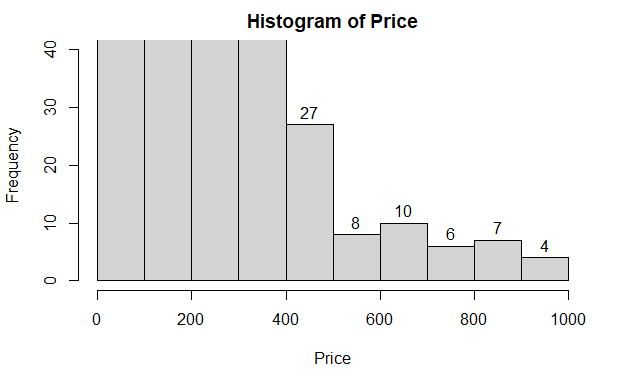

```r
# histogram with added parameters
Price <- w_df$price
h <- hist(Price,ylim=c(0,40))
text(h$mids,h$counts,labels=h$counts, adj=c(0.5, -0.5))
```

[figure not shown]

```r
library(dataRetrieval)
library(ggplot2)
# Get chloride data using dataRetrieval:
#chloride <- readNWISqw("04085139", "00940")
# Add a month column:
#w_df$property_type <- property_type.abb[as.numeric(format(w_df$property_type, "%m"))]
#w_df$property_type <- factor(w_df$property_type, levels = property_type)
# Pull out the official parameter and site names for labels:
cl_name <- attr(w_df, "variableInfo")[["parameter_nm"]]
cl_site <- attr(w_df, "siteInfo")[["station_nm"]]
# Create basic ggplot graph:
ggplot(data = w_df,
       aes(x = property_type, y = price)) +
  geom_boxplot() +
  xlab("Types of Private room") +
  ylab(cl_name) +
  labs(title = cl_site)
```

### Room types along with prices. boxes shows that on x-axis we have room types and on y-axis we have prices.

# 2. Census Dataset

## 2.1. Read in the 2011 dataset into a dataframe. Show the structure of the dataframe.

```r
library("readxl")
my_data <- read_excel("censusdata.xlsx")
colnames(my_data) <- c('Stat','Count/Percentage')
my_data = my_data[-1,]

names(my_data)
```

```
[1] "Stat"             "Count/Percentage"
```

```r
#str(my_data)
```

```r
print(my_data)
```

| Stat | Count/Percentage |
| --- | --- |
| Region | Banyule |
| None (includes bedsitters) | 78/0.2 |
| 1 bedroom | 1287/2.9 |
| 2 bedrooms | 8457/19.4 |
| 3 bedrooms | 21865/50 |
| 4 or more bedrooms | 11366/26 |
| Number of bedrooms not stated | 645/1.5 |
| Average number of bedrooms per dwelling | 3.1/-- |
| Average number of people per household | 2.6/-- |
| Region | Bayside (C) |

[output cut: 260 more lines]

## 2.2 Investigate and fix if there are any inconsistent values in the first column.

### we found above that none is found in column 1 and column 2 have its values so we want to fix it

```r
library(dplyr)
library(stringr)

my_data %>%
  mutate(across('Stat', str_replace, 'None', ' '))
```

| Stat | Count/Percentage |
| --- | --- |
| Region | Banyule |
| (includes bedsitters) | 78/0.2 |
| 1 bedroom | 1287/2.9 |
| 2 bedrooms | 8457/19.4 |
| 3 bedrooms | 21865/50 |
| 4 or more bedrooms | 11366/26 |
| Number of bedrooms not stated | 645/1.5 |
| Average number of bedrooms per dwelling | 3.1/-- |
| Average number of people per household | 2.6/-- |
| Region | Bayside (C) |

[output cut: 260 more lines]

## 2.3 . You can see that the second column contains both count and percentage. Let split the two values into 2 columns

```r
#my_data <- my_data %>% separate(Count/Percentage, c('Count', 'Percentage'))
my_data[c('Count', 'Percentage')] <- str_split_fixed(my_data$`Count/Percentage`, '/', 2)
```

```r
print(my_data)
```

| Stat | Count/Percentage | Count | Percentage |
| --- | --- | --- | --- |
| Region | Banyule | Banyule |  |
| None (includes bedsitters) | 78/0.2 | 78 | 0.2 |
| 1 bedroom | 1287/2.9 | 1287 | 2.9 |
| 2 bedrooms | 8457/19.4 | 8457 | 19.4 |
| 3 bedrooms | 21865/50 | 21865 | 50 |
| 4 or more bedrooms | 11366/26 | 11366 | 26 |
| Number of bedrooms not stated | 645/1.5 | 645 | 1.5 |
| Average number of bedrooms per dwelling | 3.1/-- | 3.1 | -- |
| Average number of people per household | 2.6/-- | 2.6 | -- |
| Region | Bayside (C) | Bayside (C) |  |

[output cut: 260 more lines]

```r
drop <- c("Count/Percentage")
df = my_data[,!(names(my_data) %in% drop)]
print(df)
```

| Stat | Count | Percentage |
| --- | --- | --- |
| Region | Banyule |  |
| None (includes bedsitters) | 78 | 0.2 |
| 1 bedroom | 1287 | 2.9 |
| 2 bedrooms | 8457 | 19.4 |
| 3 bedrooms | 21865 | 50 |
| 4 or more bedrooms | 11366 | 26 |
| Number of bedrooms not stated | 645 | 1.5 |
| Average number of bedrooms per dwelling | 3.1 | -- |
| Average number of people per household | 2.6 | -- |
| Region | Bayside (C) |  |

[output cut: 260 more lines]

```r
t1 <- df %>% group_by(Stat
) %>% slice(1)
df_new<-as.data.frame(t(t1))
print(df_new)
```

|  | V1 | V2 | V3 | V4 | V5 | V6 | V7 | V8 | V9 | V10 |
| --- | --- | --- | --- | --- | --- | --- | --- | --- | --- | --- |
| Stat | 1 bedroom | 2 bedrooms | 3 bedrooms | 4 or more bedrooms | 4+ bedrooms | Average number of bedrooms per dwelling | Average number of people per household | None (includes bedsitters) | Number of bedrooms not stated | Region |
| Count | 1287 | 8457 | 21865 | 11366 | 6187 | 3.1 | 2.6 | 78 | 645 | Banyule |
| Percentage | 2.9 | 19.4 | 50 | 26 | 15.8 | -- | -- | 0.2 | 1.5 |  |

## 2.5 Remove the percentage column.

```r
drop <- c("Percentage")
df = df[,!(names(df) %in% drop)]
print(df)
```

| Stat | Count |
| --- | --- |
| Region | Banyule |
| None (includes bedsitters) | 78 |
| 1 bedroom | 1287 |
| 2 bedrooms | 8457 |
| 3 bedrooms | 21865 |
| 4 or more bedrooms | 11366 |
| Number of bedrooms not stated | 645 |
| Average number of bedrooms per dwelling | 3.1 |
| Average number of people per household | 2.6 |
| Region | Bayside (C) |

[output cut: 260 more lines]

```r
NA
```

## 2.6 Add the year column showing the year of the data

```r
#define new column to add
year <- c(2011)

#add column called 'new'
df_new$year <- year
data <- df_new[, c("year", "V1", "V2", "V3", "V4", "V5","V6","V7", "V8")]
colnames(data)[2] = "br_count_0"
colnames(data)[3] = "br_count_1"
colnames(data)[4] = "br_count_2"
colnames(data)[5] = "br_count_3"
colnames(data)[6] = "br_count_4_or_more"
colnames(data)[7] = "br_count_unstated"
colnames(data)[8] = "av_per_dwelling"
colnames(data)[9] = "av_per_household"
data = data[-1,]
print(data)
```

|  | year | br_count_0 | br_count_1 | br_count_2 | br_count_3 | br_count_4_or_more | br_count_unstated | av_per_dwelling | av_per_household |
| --- | --- | --- | --- | --- | --- | --- | --- | --- | --- |
| Count | 2011 | 1287 | 8457 | 21865 | 11366 | 6187 | 3.1 | 2.6 | 78 |
| Percentage | 2011 | 2.9 | 19.4 | 50 | 26 | 15.8 | -- | -- | 0.2 |

```r
require(tidyverse)
unique_values<- list(unique(my_data$Count))
regions=gsub('[[:digit:]]+', '', unique_values)
#
print(regions)
```

```
[1] "c(\"Banyule\", \"\", \"\", \"\", \"\", \"\", \"\", \".\", \".\", \"Bayside (C)\", \"\", \"\", \"\", \"\", \"\", \"\", \"Boroondara (C)\", \"\", \"\", \"\", \"\", \"|.\", \"\", \"\", \"Brimbank (C)\", \"\", \"\", \"|.\", \"\", \"\", \"\", \".\", \".\", \"Cardinia (S)\", \"\", \"\", \"\", \"\", \…
```

## 2.8 Define a function that takes a year

```r
new.function <- function(a) {
      colnames(my_data) <- c('Stat','Count/Percentage')
      my_data = my_data[-1,]

      my_data[c('Count', 'Percentage')] <-                                           str_split_fixed(my_data$`Count/Percentage`, '/', 2)
      drop <- c("Count/Percentage")
      df = my_data[,!(names(my_data) %in% drop)]

      drop <- c("Percentage")
      df = df[,!(names(df) %in% drop)]
      #define new column to add
      year <- c(a)
      df_new$year <- year
      data <- df_new[, c("year", "V1", "V2", "V3", "V4", "V5","V6","V7", "V8")]
      colnames(data)[2] = "br_count_0"
      colnames(data)[3] = "br_count_1"
      colnames(data)[4] = "br_count_2"
      colnames(data)[5] = "br_count_3"
      colnames(data)[6] = "br_count_4_or_more"
      colnames(data)[7] = "br_count_unstated"
      colnames(data)[8] = "av_per_dwelling"
      colnames(data)[9] = "av_per_household"
      data = data[-1,]
      print(data)
     }


new.function(2011)
```

|  | year | br_count_0 | br_count_1 | br_count_2 | br_count_3 | br_count_4_or_more | br_count_unstated | av_per_dwelling | av_per_household |
| --- | --- | --- | --- | --- | --- | --- | --- | --- | --- |
| Count | 2011 | 1287 | 8457 | 21865 | 11366 | 6187 | 3.1 | 2.6 | 78 |
| Percentage | 2011 | 2.9 | 19.4 | 50 | 26 | 15.8 | -- | -- | 0.2 |

```r
### for 2011
df1<-new.function(2011)
```

|  | year | br_count_0 | br_count_1 | br_count_2 | br_count_3 | br_count_4_or_more | br_count_unstated | av_per_dwelling | av_per_household |
| --- | --- | --- | --- | --- | --- | --- | --- | --- | --- |
| Count | 2011 | 1287 | 8457 | 21865 | 11366 | 6187 | 3.1 | 2.6 | 78 |
| Percentage | 2011 | 2.9 | 19.4 | 50 | 26 | 15.8 | -- | -- | 0.2 |

```r
print(df1)
```

|  | year | br_count_0 | br_count_1 | br_count_2 | br_count_3 | br_count_4_or_more | br_count_unstated | av_per_dwelling | av_per_household |
| --- | --- | --- | --- | --- | --- | --- | --- | --- | --- |
| Count | 2011 | 1287 | 8457 | 21865 | 11366 | 6187 | 3.1 | 2.6 | 78 |
| Percentage | 2011 | 2.9 | 19.4 | 50 | 26 | 15.8 | -- | -- | 0.2 |

```r
### for 2016
df2=new.function(2016)
```

|  | year | br_count_0 | br_count_1 | br_count_2 | br_count_3 | br_count_4_or_more | br_count_unstated | av_per_dwelling | av_per_household |
| --- | --- | --- | --- | --- | --- | --- | --- | --- | --- |
| Count | 2016 | 1287 | 8457 | 21865 | 11366 | 6187 | 3.1 | 2.6 | 78 |
| Percentage | 2016 | 2.9 | 19.4 | 50 | 26 | 15.8 | -- | -- | 0.2 |

```r
print(df2)
```

|  | year | br_count_0 | br_count_1 | br_count_2 | br_count_3 | br_count_4_or_more | br_count_unstated | av_per_dwelling | av_per_household |
| --- | --- | --- | --- | --- | --- | --- | --- | --- | --- |
| Count | 2016 | 1287 | 8457 | 21865 | 11366 | 6187 | 3.1 | 2.6 | 78 |
| Percentage | 2016 | 2.9 | 19.4 | 50 | 26 | 15.8 | -- | -- | 0.2 |

## 2.10 . Investigate the combined dataframe

```r
combined <- rbind(df1, df2)
summary(combined)
```

```
      year       br_count_0         br_count_1         br_count_2
 Min.   :2011   Length:4           Length:4           Length:4
 1st Qu.:2011   Class :character   Class :character   Class :character
 Median :2014   Mode  :character   Mode  :character   Mode  :character
 Mean   :2014
 3rd Qu.:2016
 Max.   :2016
  br_count_3        br_count_4_or_more br_count_unstated
 Length:4           Length:4           Length:4
 Class :character   Class :character   Class :character
 Mode  :character   Mode  :character   Mode  :character



 av_per_dwelling    av_per_household
 Length:4           Length:4
 Class :character   Class :character
 Mode  :character   Mode  :character
```

### the datatype of columns are changed now

## 2.11 How many houses with 2 or 3 bedrooms in 2016

```r
df2$br_count_2 <- as.numeric(as.character(df2$br_count_2))
df2$br_count_3 <- as.numeric(as.character(df2$br_count_3))
counts=df2$br_count_2 + df2$br_count_3
cat("houses with 2 or 3 bedrooms in 2016 are:",counts[1])
```

[output not shown]

```r
#strsplit(counts, split = " ")
```

```r
library(dplyr)     # load the package in your work environment
df_count<-df
df_count<-str_replace_all(df_count$Count, "[[:digit:]]", "")
# df_count %>%
#    group_by(Count) %>%      # group your data based on the variable Rating
#    arrange(desc(regions)) %>%     # order in descending order the variable One_Year_Return
#    slice(1)
print(df_count)
```

```
  [1] "Banyule"               ""
  [3] ""                      ""
  [5] ""                      ""
  [7] ""                      "."
  [9] "."                     "Bayside (C)"
 [11] ""                      ""
 [13] ""                      ""
 [15] ""                      ""
 [17] "."                     "."
 [19] "Boroondara (C)"        ""
 [21] ""                      ""
 [23] ""                      "|."
 [25] ""                      ""
 [27] "."                     "Brimbank (C)"
 [29] ""                      ""
```

[output cut: 120 more lines]